# Horowitz (2011) - Applied Nonparametric IV - Replication on R and simulations

Louis Sirugue

December 2018

The following packages are needed to properly go through the code.

```r
list.of.packages <- c("ggplot2", "ggpubr", "MASS", "pracma", "dplyr")
new.packages <- list.of.packages[!(list.of.packages %in% installed.packages()[,"Package"])]
if(length(new.packages)) install.packages(new.packages, repos = "http://cran.us.r-project.org")
lapply(list.of.packages, library, character.only = TRUE)
```

### 1. Introduction

In this report I will consider endogeneity due to measurement error. I first generate two random variables $\nu$ and $\epsilon$ of size $n = 10,000$ such that $\nu , \epsilon \sim \mathcal{N}(0,1)$ and $cov(\nu,\epsilon) = 0.7.$ I then generate the instrument variable and the exogenous part of the explanatory variable such that $W \sim \mathcal{N}(15,1)$, $X^{*} \sim \mathcal{N}(10,1)$ and $cov(X^{*}, W) = 0.9.$ The model of interest is $y = g(X^{*}) + \epsilon,$ but one would only observe $X = X^{*} + \nu$. The results depicted in the following table ensure that I modeled endogeneity correctly.

```r
#Parametrize the simulation.
n <- 10000
mean_x <- 10
var_x <- 1
mean_w <- 15
var_w <- 1
endogeneity <- 0.7
relevance <- 0.9
cov_xw <- relevance*sqrt(var_x)*sqrt(var_w)

#Generate the variables needed to model endogeneity due to omitted variable.
set.seed(1)
nu_epsilon <- mvrnorm(n, c(0, 0), matrix(c(1, endogeneity, endogeneity, 1), 2, 2))
nu <- nu_epsilon[,1]
epsilon <- nu_epsilon[,2]
x_w <- mvrnorm(n, c(mean_x, mean_w), matrix(c(var_x, cov_xw, cov_xw, var_w), 2, 2))
x <- x_w[,1]
w <- x_w[,2]
x_obs <- x + nu

#Check that endogeneity is modeled properly.
Coefficients <- c(round(summary(lm(x_obs~epsilon))$coefficient[2,1], 3),
                  round(summary(lm(x_obs~w))$coefficient[2,1], 3),
                  round(summary(lm(w~epsilon))$coefficient[2,1], 3),
                  round(summary(lm(x~epsilon))$coefficient[2,1], 3),
                  round(summary(lm(x~nu))$coefficient[2,1], 3))
P_values <- c(round(summary(lm(x_obs~epsilon))$coefficient[2,4], 3),
              round(summary(lm(x_obs~w))$coefficient[2,4], 3),
              round(summary(lm(w~epsilon))$coefficient[2,4], 3),
              round(summary(lm(x~epsilon))$coefficient[2,4], 3),
              round(summary(lm(x~nu))$coefficient[2,4], 3))
check_table <- data.frame(Coefficients, P_values,
                          row.names = c("Observed X on epsilon", "Observed X on W", "W on epsilon",
                                        "True X on epsilon", "True X on nu"))
print(check_table)
```

```
##                       Coefficients P_values
## Observed X on epsilon        0.708    0.000
## Observed X on W              0.909    0.000
## W on epsilon                -0.001    0.942
## True X on epsilon            0.000    0.994
## True X on nu                -0.003    0.764
```

Usually, one will assume a linear relationship between $X$ and $Y$. If the true relationship is indeed linear, for instance $g(x) = 3x$, we obtain the results depicted in the following table. It shows the attenuation bias of endogeneity due to measurement errors, and that TSLS yields a good approximation, when all the assumptions hold.

```r
#Illustrate the bias of OLS and how TSLS overcomes it.
y <- (3 * x) + epsilon
xhat <- fitted.values(lm(x_obs ~ w))
Coefficients <- c(round(summary(lm(y ~ x))$coefficients[2,1], 2),
                  round(summary(lm(y ~ x_obs))$coefficients[2,1], 2),
                  round(summary(lm(y ~ xhat))$coefficients[2,1], 2))
P_values <- c(round(summary(lm(y ~ x))$coefficients[2,4], 2),
              round(summary(lm(y ~ x_obs))$coefficients[2,4], 2),
              round(summary(lm(y ~ xhat))$coefficients[2,4], 2))
#ivmodel(y,x,w) for corrected standard errors (<2e-16 as well)
linear_results <- data.frame(Coefficients, P_values,
                             row.names = c("OLS with true X", "OLS with observed X", "TSLS"))
print(linear_results)
```

```
##                     Coefficients P_values
## OLS with true X             3.00        0
## OLS with observed X         1.86        0
## TSLS                        3.00        0
```

However, if the relationship between $X$ and $Y$ is not linear, the TSLS estimation may not be relevant anymore. Indeed, if instead of considering $g(x) = 3x$, the true relationship is $g(x) = (x-10)^{3} + 250$, using TSLS would of course be quite misleading. The rest of this section will be organized as follows. Section 2 will introduce the implementation of the estimation procedure developed by Horowitz, using Legendre polynomials as basis functions. In section 3 will be discussed the precision of nonparametric IV estimation compared to the “false” precision of parametric models, while subsection 4 will conclude by discussing how parametric and nonparametric estimators behave when relaxing core assumptions.

### 2. Nonparametric estimations

Since Legendre polynomials form an orthogonal basis in $L_2[-1,1]$, they can be used as basis functions for nonparametric estimation. The first four polynomials, as used by Horowitz (2011), can be defined as such:

$$\begin{align*}
\forall\;\;x\in[-1,1],\quad L_0(x) &= 1\\
L_1(x) &= \sqrt{3}x\\
L_2(x) &= \frac{1}{2}\sqrt{5}(3x^2-1)\\
L_3(x) &= \frac{1}{2}\sqrt{7}(5x^3-3x)
\end{align*}$$

Using this basis functions and Horowitz’s estimation procedure, one can replicate the figure 3 of Horowitz (2011) which considers test scores as a function of class size (figure below), using the data of Angrist and Lavy (1999).

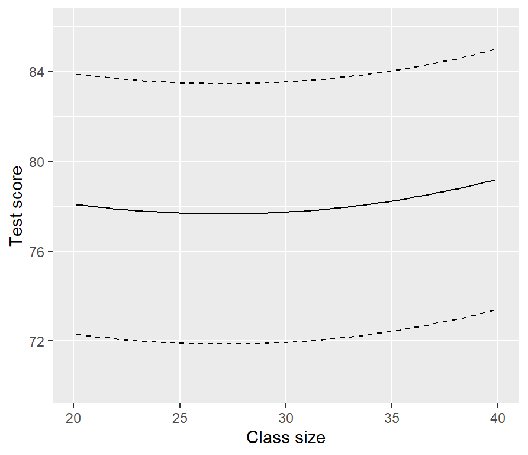

```r
####################################################
#1. Define step by step the Legendre basis function#
####################################################

rm(list=ls())

#Procedure to normalize vector to unit interval.
normalize <- function(x) x <- (x - min(x))/(max(x) - min(x))

#Procedure to get Legendre basis function.
bfunc <- function(x,nf) {
  z <- 2*x - 1
  rz <- length(z)
  psi <- matrix(0, nrow=rz, ncol=10)
  psi[,1] <- replicate(rz,1)
  psi[,2] <- (sqrt(3))*z
  psi[,3] <- 0.5*(sqrt(5))*(3*(z^2) - 1)
  psi[,4] <- 0.5*(sqrt(7))*(5*(z^3) - 3*z)
  psi[,5] <- 0.125*3*(35*(z^4) - 30*(z^2) + 3)
  psi[,6] <- 0.125*(sqrt(11))*(63*(z^5) - 70*(z^3) + 15*z)
  psi[,7] <- 0.0625*(sqrt(13))*(231*(z^6) - 315*(z^4) + 105*(z^2) - 5)
  psi[,8] <- 0.0625*(sqrt(15))*(429*(z^7) - 693*(z^5) + 315*(z^3) - 35*z)
  psi[,9] <- (1/128)*(sqrt(17))*(6435*(z^8) - 12012*(z^6) + 6930*(z^4) - 1260*(z^2) + 35)
  psi[,10] <- (1/128)*(sqrt(19))*(12155*(z^9) - 25740*(z^7) + 18018*(z^5) - 4620*(z^3) + 315*z)
  psi <- psi[,1:(nf+1)]
  return(psi)
}

#Procedure to find bootstrap uniform confidence intervals.
bootstr <- function(bhat, invaht, delbar, data=wxy, degree=3, clvl=0.95, nboot=1000, xx) {
  clvl <- clvl*nboot
  maxt <- vector(mode="numeric", length=nboot)
  for (iboot in 1:nboot) {
    #Draw bootstrap sample
    vboot <- data[sample(1:nrow(data), nrow(data), replace=T),]

    #Select data
    wboot <- vboot[,1]
    xboot <- vboot[,2]
    yboot <- vboot[,3]
    xboot <- normalize(xboot)
    wboot <- normalize(wboot)

    #Estimate Fourier coefficients
    xxb <- bfunc(xboot, degree)
    wwb <- bfunc(wboot, degree)
    bhbt <- solve(t(wwb) %*% xxb) %*% t(wwb) %*% yboot

    uboot <- yboot - xxb %*% bhat
    delbt <- t(wwb) %*% uboot
    swig <- xx %*% invaht %*% delbt - delbar
    tstat <- abs(swig)

    maxt[iboot] <- max(tstat)
  }
  maxt <- sort(maxt)
  return(maxt[clvl])
}

#Procedure to get curve and CI for nonparametric IV with Legendre basis.
npiv_legendre <- function(y, x, w, deg=4, n_graph=100, n_boot=1000, conf_level=0.95, bootstrap=T, xrange=NULL) {

  #Transform X and W to Unit Interval
  n <- length(y)
  x_norm <- normalize(x)
  w_norm <- normalize(w)

  #Create grid for graphs
  if (is.null(xrange)) {
    del <- (max(x_norm) - min(x_norm))/(n_graph+1)
    x0 <- min(x_norm) + del
    grid <- seq(from=x0, by=del, length.out=n_graph)
    gr0 <- grid*(max(x) - min(x)) + min(x)
  } else {
    xrange_1 <- (xrange[1]-min(x))/(max(x) - min(x))
    xrange_2 <- (xrange[2]-min(x))/(max(x) - min(x))
    grid <- seq(from=xrange_1, to=xrange_2, length.out=n_graph)
    gr0 <- seq(from=xrange[1], to=xrange[2], length.out=n_graph)
  }
  #Estimate Fourier coefficients
  xx <- bfunc(x_norm, deg)
  ww <- bfunc(w_norm, deg)
  xgrid <- bfunc(grid, deg)

  invaht <- solve(t(ww) %*% xx)
  bhat <- invaht %*% t(ww) %*% y
  yhat <- xgrid %*% bhat

  #Use bootstrap to get confidence band
  uhat <- y - xx %*% bhat
  delbar <- xx %*% invaht %*% colMeans(apply(ww, 2, function(x) uhat*x))
  wxy <- data.frame(w,x,y)

  #Bootstrap s.e., if specified. Return final data
  if (bootstrap==T) {
    cval <- bootstr(bhat, invaht, delbar, data=wxy, degree=deg, clvl=conf_level, nboot=n_boot, xx=xx)
    return(data.frame(x=gr0, yhat, ylow=yhat-cval, yhigh=yhat+cval))
  } else {
    return(data.frame(x=gr0, yhat))
  }
}

#Example from Horowitz
yz <- read.csv2(file = file.choose(), header=F)
yz <- apply(yz, 2, as.numeric)
z <- yz[,6] ; yz <- yz[z<=3,]
y <- yz[,5] ; x <- yz[,3] ; w <- yz[,7]
data <- npiv_legendre(y, x, w, deg=3, n_boot=1000)
ggplot(data, aes(x=x)) + geom_line(aes(y=yhat)) +
  geom_line(aes(y=ylow), linetype=2) +
  geom_line(aes(y=yhigh), linetype=2) +
  scale_x_continuous("Class size", limits=c(20,40)) +
  scale_y_continuous("Test score", breaks = c(72,76,80,84), limits=c(70,86))
```

B-splines, which are alternative basis functions for nonparametric estimation, are studied in Appendix (where the Engel curve of Horowitz (2011) is also replicated).

### Nonparametrics and precision

#### Misleading confidence intervals

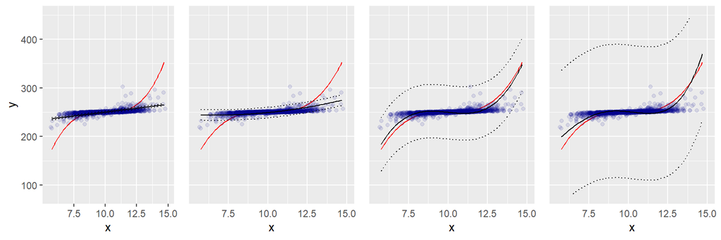

```r
n <- 2000
mean_x <- 10
var_x <- 1
mean_w <- 15
var_w <- 1
endogeneity <- 0.7
relevance <- 0.9
cov_xw <- relevance*sqrt(var_x)*sqrt(var_w)

set.seed(13)
nu_epsilon <- mvrnorm(n, c(0, 0), matrix(c(1, endogeneity, endogeneity, 1), 2, 2))
nu <- nu_epsilon[,1] ; epsilon <- nu_epsilon[,2]
x_w <- mvrnorm(n, c(mean_x, mean_w), matrix(c(var_x, relevance, relevance, var_w), 2, 2))
x <- x_w[,1] ; w <- x_w[,2]
x_obs <- x + nu
y <- 250 + ((x-10)^3) + epsilon

for (i in 1:4) {
  data <- npiv_legendre(y, x_obs, w, deg=i, n_boot=1000)
  p <- ggplot(data, aes(x=x)) +
    geom_line(data=data.frame(x=data$x, y=250+((data$x-10)^3)), aes(x,y), color="red") +
    geom_point(data=data.frame(x_obs, y), aes(x_obs,y), alpha=0.1, color="darkblue") +
    geom_line(aes(y=yhat)) +
    geom_line(aes(y=ylow), linetype=3) +
    geom_line(aes(y=yhigh), linetype=3) +
    xlim(5.5,15) + ylim(80, 450)
  if (i>1) {
    p <- p + theme(axis.title.y = element_blank(),
                   axis.text.y = element_blank(),
                   axis.ticks = element_blank())
  }
  assign(paste("plot", i, sep = ""), p)
}
ggarrange(plot1, plot2, plot3, plot4, ncol = 4, nrow = 1)
```

The leftmost subgraph represents the 2SLS estimator and its very thin 95% CI. Clearly, assuming a fixed (linear) model leads us to severely overestimate the precision of the estimator, since the true relationship between $x$ and $y$ is not included in the confidence interval. The same goes with the degree 2 estimator.

However, the estimator of degree 3 is a lot closer to the data, and the true relationship fits within the 95% CI. Here, allowing for an additional degree of flexibility is not needed, as it makes the fit slightly better but significantly increases the variance of the estimator (see the rightmost subgraph).

#### Heavy versus thin tails

Let’s now vary the heaviness of the tails of the distribution of $x$ to illustrate the implications of having few data points for some range of $x$. Consider two scenarios.

In scenario 1, I draw the couple $(x_i,w_i)$ from some *bivariate normal* distribution.

In scenario 2, I draw $(x_i,w_i)$ from a *bivariate student* distribution with 4 degrees of freedom.

In order to draw from a bivariate Student distribution with given means $(\mu_1,\mu_2)$, given variance-covariance matrix $\Sigma$, and $\tau>3$ degrees of freedom, I start by drawing:
$$\begin{align*}
&(z_{i1},z_{i2})\sim\mathcal{N}\Big(0,\Sigma(\tau-2)\Big)\\
&u_i\sim\chi^2_\tau\\[1em]
\end{align*}$$

One gets Student distributed $(x_i,w_i)$ by computing the following:
$$\begin{align*}
x_i &= \mu_1 + z_{i1}\sqrt{\frac{1}{u_i}}\\
w_i &= \mu_2 + z_{i2}\sqrt{\frac{1}{u_i}}
\end{align*}$$

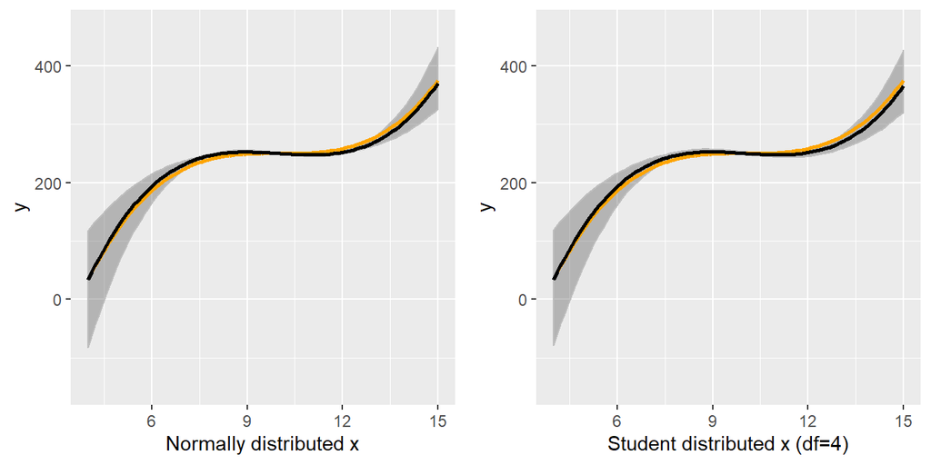

```r
### GAUSSIAN SCENARIO ###
# Run the estimation on 1000 simulations
for (z in 1:1000) {
  nu_epsilon <- mvrnorm(n, c(0, 0), matrix(c(1, endogeneity, endogeneity, 1), 2, 2))
  nu <- nu_epsilon[,1] ; epsilon <- nu_epsilon[,2]
  x_w <- mvrnorm(n, c(mean_x, mean_w), matrix(c(var_x, relevance, relevance, var_w), 2, 2))
  x <- x_w[,1] ; w <- x_w[,2]
  x_obs <- x + nu
  y <- 250 + ((x-10)^3) + epsilon
  if (z==1) {
    data <- cbind(sample = z, npiv_legendre(y, x_obs, w, deg=3, bootstrap=F, xrange=c(4,15)))
  } else {
    data <- rbind(data, cbind(sample = z, npiv_legendre(y, x_obs, w, deg=3, bootstrap=F, xrange=c(4,15))))
  }
}

# For every x, keep the mean fitted-y and the interval [ylow, yhigh] which contains 95% of fitted values
plotdf <- data %>% group_by(x) %>% summarize(yhigh = quantile(yhat, 0.95), ylow = quantile(yhat, 0.05), yhat=mean(yhat)) %>% ungroup()
plot1 <- ggplot(plotdf) +
  geom_ribbon(aes(x, ymin=ylow, ymax=yhigh), alpha=0.3, color="gray") +
  geom_line(data=data.frame(x=data$x, y=250+((data$x-10)^3)), aes(x,y), color="orange", size=1) +
  geom_line(aes(x,yhat), size=1) + scale_y_continuous(limits=c(-150, 465)) + scale_x_continuous("Normally distributed x")


### STUDENT SCENARIO ###
# Run the estimation on 1000 simulations
for (z in 1:1000) {
  nu_epsilon <- mvrnorm(n, c(0, 0), matrix(c(1, endogeneity, endogeneity, 1), 2, 2))
  nu <- nu_epsilon[,1] ; epsilon <- nu_epsilon[,2]
  df <- 4
  s_norm <- mvrnorm(n, c(0,0), matrix(c(var_x, relevance, relevance, var_w)*(df-2), 2))
  x_w <- t(t(s_norm * sqrt(1/rchisq(n,df))) + c(mean_x, mean_w))
  x <- x_w[,1] ; w <- x_w[,2]
  x_obs <- x + nu
  y <- 250 + ((x-10)^3) + epsilon
  if (z==1) {
    data <- cbind(sample = z, npiv_legendre(y, x_obs, w, deg=3, bootstrap=F, xrange=c(4,15)))
  } else {
    data <- rbind(data, cbind(sample = z, npiv_legendre(y, x_obs, w, deg=3, bootstrap=F, xrange=c(4,15))))
  }
}

# For every x, keep the mean fitted-y and the interval [ylow, yhigh] which contains 95% of fitted values
plotdf <- data %>% group_by(x) %>% summarize(yhigh = quantile(yhat, 0.95), ylow = quantile(yhat, 0.05), yhat=mean(yhat)) %>% ungroup()
plot2 <- ggplot(plotdf) +
  geom_ribbon(aes(x, ymin=ylow, ymax=yhigh), alpha=0.3, color="gray") +
  geom_line(data=data.frame(x=data$x, y=250+((data$x-10)^3)), aes(x,y), color="orange", size=1) +
  geom_line(aes(x,yhat), size=1) + scale_y_continuous(limits=c(-150, 465)) + scale_x_continuous("Student distributed x (df=4)")

ggarrange(plot1, plot2, ncol = 2, nrow = 1)
```

Given these simulations, the estimator seems quite robust to the amount of mass at the tails of the distribution.

### Relaxing assumptions

The TSLS estimator relies on both the exogeneity and relevance assumptions. Indeed, as we can see with the following formula, a small amount of endogeneity in the instrument can make the bias grow fast if the instrument is weak.

$$plim(\hat{\beta}_{2SLS})=\beta + \frac{cov(W,\epsilon)}{cov(W, X)}$$

The figure below illustrates this property, with the same setting as described in the introduction, but with $cov(W,\epsilon)=0.2$ and a correlation between the instrument and the endogenous variable that decreases from $0.9$ to $0.1$ (the true relationship is the red curve while estimated linear relationships are darker as the relevance of the instrument decreases).

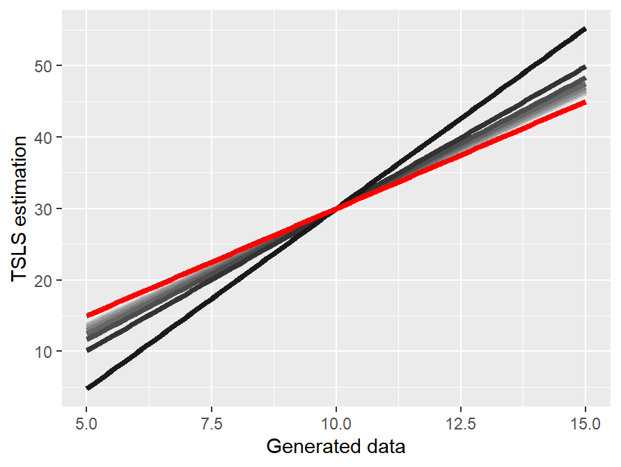

```r
n <- 10000
endogeneity <- 0.7
mean_x <- 10
var_x <- 1
mean_w <- 15
var_w <- 1
bias <- 0.2

meancoeffs <- vector(mode = "numeric", length = 0)
meancsts <- vector(mode = "numeric", length = 0)

set.seed(1)
for (i in (seq(0.1, 0.9, 0.1))){
  TSLScoeffs <- vector(mode = "numeric", length = 0)
  TSLScsts <- vector(mode = "numeric", length = 0)
  for (j in (1:100)){
    relevance <- i
    cov_xw <- relevance*sqrt(var_x)*sqrt(var_w)


    nu_epsilon_x_w <- mvrnorm(n, c(0, 0, mean_x, mean_w), matrix(c(1, endogeneity, 0, 0, endogeneity, 1, 0, bias, 0, 0, 1,
                                                                   cov_xw, 0, bias, cov_xw, 1), 4, 4))
    nu <- nu_epsilon_x_w[,1]
    epsilon <- nu_epsilon_x_w[,2]
    x <- nu_epsilon_x_w[,3]
    w <- nu_epsilon_x_w[,4]
    x_obs <- x + nu

    y <- (3 * x) + epsilon
    xhat <- fitted.values(lm(x_obs ~ w))

    TSLScoeffs <- c(TSLScoeffs, summary(lm(y ~ xhat))$coefficients[2,1])
    TSLScsts <- c(TSLScsts, summary(lm(y ~ xhat))$coefficients[1,1])
  }
  meancoeff <- mean(TSLScoeffs)
  meancoeffs <- c(meancoeffs, meancoeff)
  meancst <- mean(TSLScsts)
  meancsts <- c(meancsts, meancst)
}

x <- seq(5, 15, 0.1)
true <- 3 * x
data_weak <- data.frame(x, true)
for (i in (1:length(meancoeffs))){
  TSLS <- (meancoeffs[i] * x) + meancsts[i]
  data_weak <- data.frame(data_weak, TSLS)
}

ggplot(data_weak, aes(x)) +
  geom_line(aes(y = TSLS.8), color = "grey90", size = 1.5) +
  geom_line(aes(y = TSLS.7), color = "grey80", size = 1.5) +
  geom_line(aes(y = TSLS.6), color = "grey70", size = 1.5) +
  geom_line(aes(y = TSLS.5), color = "grey60", size = 1.5) +
  geom_line(aes(y = TSLS.4), color = "grey50", size = 1.5) +
  geom_line(aes(y = TSLS.3), color = "grey40", size = 1.5) +
  geom_line(aes(y = TSLS.2), color = "grey30", size = 1.5) +
  geom_line(aes(y = TSLS.1), color = "grey20", size = 1.5) +
  geom_line(aes(y = TSLS), color = "grey10", size = 1.5) +
  geom_line(aes(y = true), color = "red", size = 1.5) +
  labs(x = "Generated data", y = "TSLS estimation")
```

The following figures depict how nonparametric estimations would behave in that very setting. In the left figure, the black line is the true relationship and the grayscale curves represent the nonparametric estimations, the darker the line the lower the relevance of the instrument (from 0.9 to 0.6). In this setting, an instrument’s correlation with the endogenous variable no larger than 0.6 can already yield very misleading results. But the thing that must be emphasized on is that the confidence intervals become progressively larger as the assumptions start to be violated. This strengthens the point made by Horowitz that a great interest of nonparametrics is that it avoids “false precision”.

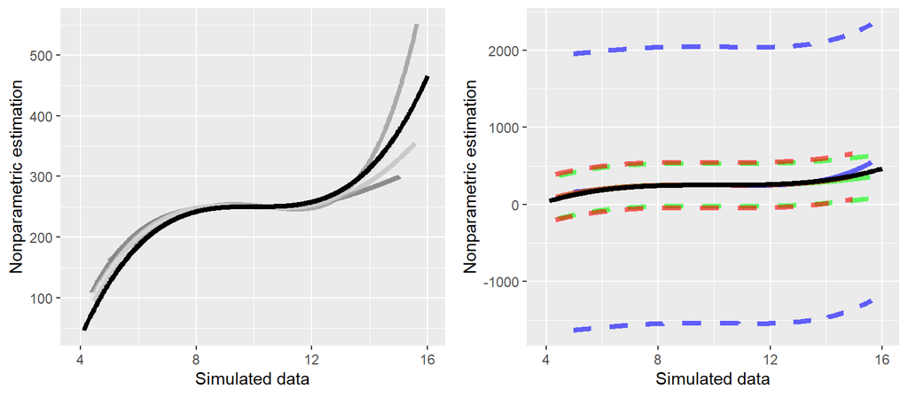

```r
Np_data <- data.frame(seq(1,100,1))

set.seed(1)
for (i in (seq(0.1, 0.9, 0.1))){
  x_vect <- vector(mode = "numeric", length = 0)
  y_vect <- vector(mode = "numeric", length = 0)
  relevance <- i
  cov_xw <- relevance*sqrt(var_x)*sqrt(var_w)

  nu_epsilon_x_w <- mvrnorm(n, c(0, 0, mean_x, mean_w), matrix(c(1, endogeneity, 0, 0, endogeneity, 1, 0, bias, 0, 0, 1,
                                                                 cov_xw, 0, bias, cov_xw, 1), 4, 4))
  nu <- nu_epsilon_x_w[,1]
  epsilon <- nu_epsilon_x_w[,2]
  x <- nu_epsilon_x_w[,3]
  w <- nu_epsilon_x_w[,4]
  x_obs <- x + nu

  y <- 250 + ((x-10)^3) + epsilon
  Np_data <- data.frame(Np_data, npiv_legendre(y, x_obs, w, deg=4, n_boot=100))
}

x <- seq(4.12, 16, 0.12)
true <- 250 + ((x-10)^3)
Np_data <- data.frame(Np_data, x, true)

x_sequence <- seq(2, (dim(Np_data)[2] - 1), 4)
all_xs <- vector(mode = "numeric", length = 0)
for (i in x_sequence){
  all_xs <- c(all_xs, Np_data[,i])
}

all_unique_x <- unique(all_xs)
graph_data <- data.frame(all_unique_x)

y_sequence <- seq(3, (dim(Np_data)[2]), 4)
for (i in y_sequence){
  oldy <- Np_data[,i]
  corresponding_x <- Np_data[,i-1]
  newy <- rep(NA, length(all_unique_x))
  indices <- match(corresponding_x, all_unique_x)
  newy[indices] <- oldy
  graph_data <- data.frame(graph_data, newy)
}

ylow_sequence <- seq(4, (dim(Np_data)[2] - 3), 4)
for (i in ylow_sequence){
  oldylow <- Np_data[,i]
  corresponding_x <- Np_data[,i-2]
  newylow <- rep(NA, length(all_unique_x))
  indices <- match(corresponding_x, all_unique_x)
  newylow[indices] <- oldylow
  graph_data <- data.frame(graph_data, newylow)
}

yhigh_sequence <- seq(5, (dim(Np_data)[2] - 2), 4)
for (i in yhigh_sequence){
  oldyhigh <- Np_data[,i]
  corresponding_x <- Np_data[,i-3]
  newyhigh <- rep(NA, length(all_unique_x))
  indices <- match(corresponding_x, all_unique_x)
  newyhigh[indices] <- oldyhigh
  graph_data <- data.frame(graph_data, newyhigh)
}

truey <- with(graph_data, interp1(all_unique_x, newy.9, all_unique_x, "linear"))
y6 <- with(graph_data, interp1(all_unique_x, newy.5, all_unique_x, "linear"))
y7 <- with(graph_data, interp1(all_unique_x, newy.6, all_unique_x, "linear"))
y8 <- with(graph_data, interp1(all_unique_x, newy.7, all_unique_x, "linear"))
y9 <- with(graph_data, interp1(all_unique_x, newy.8, all_unique_x, "linear"))
# lower bounds
yl7 <- with(graph_data, interp1(all_unique_x, newylow.6, all_unique_x, "linear"))
yl8 <- with(graph_data, interp1(all_unique_x, newylow.7, all_unique_x, "linear"))
yl9 <- with(graph_data, interp1(all_unique_x, newylow.8, all_unique_x, "linear"))
# upper bounds
yh7 <- with(graph_data, interp1(all_unique_x, newyhigh.6, all_unique_x, "linear"))
yh8 <- with(graph_data, interp1(all_unique_x, newyhigh.7, all_unique_x, "linear"))
yh9 <- with(graph_data, interp1(all_unique_x, newyhigh.8, all_unique_x, "linear"))

new_data <- data.frame(all_unique_x, truey, y6, y7, y8, y9, yl7, yl8, yl9, yh7, yh8, yh9)

#Plot the results
plot1 <- ggplot(new_data, aes(x = all_unique_x)) +
  geom_line(aes(y = y6), alpha = 0.6, color = "grey30", size = 1.5) +
  geom_line(aes(y = y7), alpha = 0.6, color = "grey50", size = 1.5) +
  geom_line(aes(y = y8), alpha = 0.6, color = "grey70", size = 1.5) +
  geom_line(aes(y = y9), alpha = 0.6, color = "grey90", size = 1.5) +
  geom_line(aes(y = truey), color = "black", size = 1.5) +
  labs(x = "Simulated data", y = "Nonparametric estimation")

plot2 <- ggplot(new_data, aes(x = all_unique_x)) +
  geom_line(aes(y = y7), alpha = 0.6, color = "blue", size = 1.5) +
  geom_line(aes(y = yl7), alpha = 0.6, linetype = 2, color = "blue", size = 1.5) +
  geom_line(aes(y = yh7), alpha = 0.6, linetype = 2, color = "blue", size = 1.5) +
  geom_line(aes(y = y8), alpha = 0.6, color = "green", size = 1.5) +
  geom_line(aes(y = yl8), alpha = 0.6, linetype = 2, color = "green", size = 1.5) +
  geom_line(aes(y = yh8), alpha = 0.6, linetype = 2, color = "green", size = 1.5) +
  geom_line(aes(y = y9), alpha = 0.6, color = "red", size = 1.5) +
  geom_line(aes(y = yl9), alpha = 0.6, linetype = 2, color = "red", size = 1.5) +
  geom_line(aes(y = yh9), alpha = 0.6, linetype = 2, color = "red", size = 1.5) +
  geom_line(aes(y = truey), color = "black", size = 1.5) +
  labs(x = "Simulated data", y = "Nonparametric estimation")

ggarrange(plot1, plot2, ncol = 2, nrow = 1)
```

This can also be tested with another true relationship that could represent a utility curve. I model endogeneity in the same way as before, and parametrize the simulation as follows. I first generate two random variables $\nu$ and $\epsilon$ of size $n = 10,000$ such that $\nu, \epsilon \sim N(0,1)$, $cov(\nu,\epsilon) = 0.7$. I then generate the instrument variable and the exogenous part of the explanatory variable such that $W \sim N(11,1), X^{*} \sim N(6, 1), cov(X^{*}, W) = 0.9$. The true relationship that will be considered is: $g(x) = 15\ln(x + 1)$.

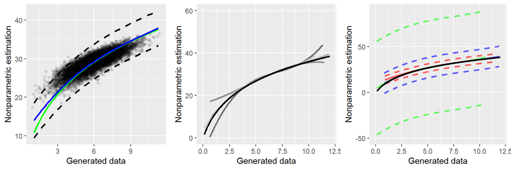

```r
endogeneity <- 0.7
mean_x <- 6
var_x <- 1
mean_w <- 11
var_w <- 1
bias <- 0
relevance <- .9

set.seed(1)
nu_epsilon_x_w2 <- mvrnorm(n, c(0, 0, mean_x, mean_w), matrix(c(1, endogeneity, 0, 0, endogeneity, 1, 0, bias, 0, 0, 1,
                                                               relevance, 0, bias, relevance, 1), 4, 4))
nu2 <- nu_epsilon_x_w2[,1]
epsilon2 <- nu_epsilon_x_w2[,2]
x2 <- nu_epsilon_x_w2[,3]
w2 <- nu_epsilon_x_w2[,4]
x_obs2 <- x2 + nu2

y2 <- (15 * log(x2 + 1)) + epsilon2
data_utility <- npiv_legendre(y2, x_obs2, w2, deg=3, n_boot=100)

#How it looks like when the assumptions hold
plot0 <- ggplot(data_utility, aes(x=x)) +
  geom_point(data=data.frame(x_obs2, y2), aes(x_obs2,y2), alpha=0.1) +
  geom_line(data=data.frame(x=data_utility$x, y=(15 * log(data_utility$x + 1))), aes(x,y), color="green", size = 1) +
  geom_line(aes(y=yhat), color = "blue", size = 1) +
  geom_line(aes(y=ylow), linetype=2, size = 1) +
  geom_line(aes(y=yhigh), linetype=2, size = 1) +
  labs(x = "Generated data", y = "Nonparametric estimation")

#Relaxing the assumptions
Np_data <- data.frame(seq(1,100,1))

set.seed(1)
for (i in (seq(0.1, 0.9, 0.1))){
  x_vect <- vector(mode = "numeric", length = 0)
  y_vect <- vector(mode = "numeric", length = 0)
  relevance <- i
  cov_xw <- relevance*sqrt(var_x)*sqrt(var_w)

  nu_epsilon_x_w <- mvrnorm(n, c(0, 0, mean_x, mean_w), matrix(c(1, endogeneity, 0, 0, endogeneity, 1, 0, bias, 0, 0, 1,
                                                                 cov_xw, 0, bias, cov_xw, 1), 4, 4))
  nu <- nu_epsilon_x_w[,1]
  epsilon <- nu_epsilon_x_w[,2]
  x <- nu_epsilon_x_w[,3]
  w <- nu_epsilon_x_w[,4]
  x_obs <- x + nu

  y <- (15 * log(x + 1)) + epsilon
  Np_data <- data.frame(Np_data, npiv_legendre(y, x_obs, w, deg=3, n_boot=100))
}

x <- seq(0.12, 12, 0.12)
true <- (15 * log(x + 1))
Np_data <- data.frame(Np_data, x, true)

x_sequence <- seq(2, (dim(Np_data)[2] - 1), 4)
all_xs <- vector(mode = "numeric", length = 0)
for (i in x_sequence){
  all_xs <- c(all_xs, Np_data[,i])
}

all_unique_x <- unique(all_xs)
graph_data <- data.frame(all_unique_x)

y_sequence <- seq(3, (dim(Np_data)[2]), 4)
for (i in y_sequence){
  oldy <- Np_data[,i]
  corresponding_x <- Np_data[,i-1]
  newy <- rep(NA, length(all_unique_x))
  indices <- match(corresponding_x, all_unique_x)
  newy[indices] <- oldy
  graph_data <- data.frame(graph_data, newy)
}

ylow_sequence <- seq(4, (dim(Np_data)[2] - 3), 4)
for (i in ylow_sequence){
  oldylow <- Np_data[,i]
  corresponding_x <- Np_data[,i-2]
  newylow <- rep(NA, length(all_unique_x))
  indices <- match(corresponding_x, all_unique_x)
  newylow[indices] <- oldylow
  graph_data <- data.frame(graph_data, newylow)
}

yhigh_sequence <- seq(5, (dim(Np_data)[2] - 2), 4)
for (i in yhigh_sequence){
  oldyhigh <- Np_data[,i]
  corresponding_x <- Np_data[,i-3]
  newyhigh <- rep(NA, length(all_unique_x))
  indices <- match(corresponding_x, all_unique_x)
  newyhigh[indices] <- oldyhigh
  graph_data <- data.frame(graph_data, newyhigh)
}

truey <- with(graph_data, interp1(all_unique_x, newy.9, all_unique_x, "linear"))
y5 <- with(graph_data, interp1(all_unique_x, newy.4, all_unique_x, "linear"))
y6 <- with(graph_data, interp1(all_unique_x, newy.5, all_unique_x, "linear"))
y7 <- with(graph_data, interp1(all_unique_x, newy.6, all_unique_x, "linear"))
y8 <- with(graph_data, interp1(all_unique_x, newy.7, all_unique_x, "linear"))
y9 <- with(graph_data, interp1(all_unique_x, newy.8, all_unique_x, "linear"))
# Lower bounds
yl7 <- with(graph_data, interp1(all_unique_x, newylow.6, all_unique_x, "linear"))
yl8 <- with(graph_data, interp1(all_unique_x, newylow.7, all_unique_x, "linear"))
yl9 <- with(graph_data, interp1(all_unique_x, newylow.8, all_unique_x, "linear"))
# Upper bounds
yh7 <- with(graph_data, interp1(all_unique_x, newyhigh.6, all_unique_x, "linear"))
yh8 <- with(graph_data, interp1(all_unique_x, newyhigh.7, all_unique_x, "linear"))
yh9 <- with(graph_data, interp1(all_unique_x, newyhigh.8, all_unique_x, "linear"))

new_data <- data.frame(all_unique_x, truey, y5, y6, y7, y8, y9,  yl7, yl8, yl9, yh7, yh8, yh9)

#Plot the results
plot1 <- ggplot(new_data, aes(x = all_unique_x)) +
  geom_line(aes(y = y5), alpha = 0.6, color = "grey10", size = 1) +
  geom_line(aes(y = y6), alpha = 0.6, color = "grey30", size = 1) +
  geom_line(aes(y = y7), alpha = 0.6, color = "grey50", size = 1) +
  geom_line(aes(y = y8), alpha = 0.6, color = "grey70", size = 1) +
  geom_line(aes(y = y9), alpha = 0.6, color = "grey90", size = 1) +
  geom_line(aes(y = truey), color = "black", size = 1) +
  labs(x = "Generated data", y = "Nonparametric estimation") +
  scale_y_continuous(limits=c(0, 60)) +
  scale_x_continuous(limits=c(0, 12))

plot2 <- ggplot(new_data, aes(x = all_unique_x)) +
  geom_line(aes(y = y7), alpha = 0.6, color = "blue", size = 1) +
  geom_line(aes(y = yl7), alpha = 0.6, linetype = 2, color = "blue", size = 1) +
  geom_line(aes(y = yh7), alpha = 0.6, linetype = 2, color = "blue", size = 1) +
  geom_line(aes(y = y8), alpha = 0.6, color = "green", size = 1) +
  geom_line(aes(y = yl8), alpha = 0.6, linetype = 2, color = "green", size = 1) +
  geom_line(aes(y = yh8), alpha = 0.6, linetype = 2, color = "green", size = 1) +
  geom_line(aes(y = y9), alpha = 0.6, color = "red", size = 1) +
  geom_line(aes(y = yl9), alpha = 0.6, linetype = 2, color = "red", size = 1) +
  geom_line(aes(y = yh9), alpha = 0.6, linetype = 2, color = "red", size = 1) +
  geom_line(aes(y = truey), color = "black", size = 1) +
  scale_x_continuous(limits = c(0,12)) +
  labs(x = "Generated data", y = "Nonparametric estimation")

ggarrange(plot0, plot1, plot2, ncol = 3, nrow = 1)
```

To conclude, the main takeaway is probably that nonparametric IV is a great tool to avoid the false precision induced by the parametrization of a model. This point was confirmed by the simulations and brought one step further as we observed that precision was sensitive to the relaxation of IV core assumptions. Even though the recognition of the true relationship may not be completely transparent when ignoring the DGP (as it may be sensitive to changes in the degree of the basis function as illustrated above), Horowitz (2011) developed a convenient tool that could easily be implemented by researchers to produce convincing IV estimations.

### Appendix

One can use B-splines as basis functions for nonparametric IV estimation. B-splines are defined by their degree $k$ and their numbers of interior knots $m + 1$. The interior knots are usually evenly spaced (the B-splines function is in that case said to be uniform) on the interval $[0,1]$, and the knots set must be extended by $k$ additional knots at each bound for the function to be defined over the whole interval. Exterior knots below (resp. above) the lower (resp. upper) bound are usually set to be equal to the lower (resp. upper) bound, but these values are arbitrary. Thus, the total number of knots $\{\xi_{j} : j =-k,...,m+k \}$ is $m + 1 + 2k$ and is such that:

$$\xi_{-k} < \xi_{-k+1} < ... < -\xi_{-1} < \xi_{0} = 0 < \xi_{1} <...<\xi_{m} = 1 < \xi_{m+1} < ... <\xi_{m+k}$$

For instance, the set of knots $\Xi$ of a uniform B-splines of degree 3 and with 4 interior knots would be:

$$\Xi = \bigg\{-1, -\frac{2}{3}, -\frac{1}{3}, 0, \frac{1}{3}, \frac{2}{3}, 1, \frac{4}{3}, \frac{5}{3}, 2\bigg\}$$

The $p^{th}$ B-spline of the function is defined as:

$$B_{p}(x) = \sum_{j=p}^{p+k+1} \Big[\prod_{i=p, i\neq j}^{p+k-1} \frac{1}{\xi_{i}-\xi_{j}} \Big] (x - \xi_{j})^{k}_{+}; \hspace{0.2in} 0 \leq x \leq 1; \hspace{0.2in} p =-k, ... , m+ k;$$

$$\hat{G} = (W_{n}'X_{n})^{-1}W_{n}'Y_{n}$$

Besides, Horowitz uses the following *à la* Tikhonov stabilization method:

$$\hat{G} = (W_{n}'X_{n})^{-1}W_{n}'Y_{n}\\
= \frac{\frac{1}{n^2}(X_{n}'W_{n})(W_{n}')}{ \frac{1}{n^2}(X_{n}'W_{n})(W_{n}'X_{n})}Y_{n}\\
\approx \frac{\frac{1}{n^2}(X_{n}'W_{n})(W_{n}')}{ \frac{1}{n^2}(X_{n}'W_{n})(W_{n}'X_{n}) + a_{n}I}Y_{n},$$

where $a_{n}$ must be positive constants that tend to $0$ as $n$ tends to infinity.

The next figure replicates Horowitz’s estimation of an Engel curve using the abovementioned formula.

```r
#Define step by step the B-spline basis function
################################################

#The following function takes as arguments a number of knots (m + 1) and the degree k of the splines,
#and returns the set of (m + 1 + 2k) knots with the interior knots evenly spaced on the unit interval
#[0,1].
knot_vector <- function(mp1, k) {
  #Generate the interior knots
  knot_set <- 0
  nk1 <- mp1 - 1
  for (i in (1:nk1)) {
    lastval <- knot_set[length(knot_set)]
    newval <- lastval + (1 / nk1)
    knot_set <- c(knot_set, newval)
  }
  #Extend the lower bound
  lbound_ext <- -1/nk1
  for (i in (1:(k - 1))) {
    lastval <- lbound_ext[length(lbound_ext)]
    newval <- lastval - (1 / nk1)
    lbound_ext <- c(lbound_ext, newval)
  }
  lbound_ext <- rev(lbound_ext)
  #Extend the upper bound
  ubound_ext <- 1 + (1/nk1)
  for (i in (1:(k - 1))) {
    lastval <- ubound_ext[length(ubound_ext)]
    newval <- lastval + (1 / nk1)
    ubound_ext <- c(ubound_ext, newval)
  }

  knot_set <- c(lbound_ext, knot_set, ubound_ext)
  return(knot_set)
}

#Example of knot-set for uniform B-splines of degree 3 and with 4 interior knots:
knot_vector(4, 3)
```

```
##  [1] -1.0000000 -0.6666667 -0.3333333  0.0000000  0.3333333  0.6666667
##  [7]  1.0000000  1.3333333  1.6666667  2.0000000
```

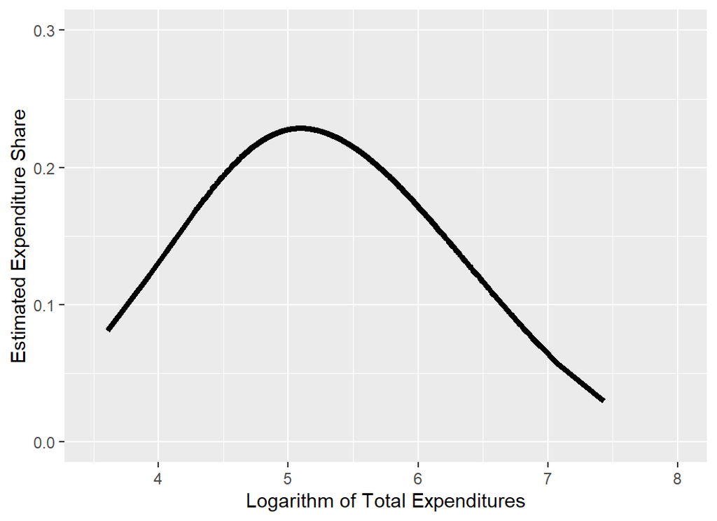

```r
#The following function takes as arguments the order of the function k and its set of knots generated
#with the previously defined function and provides what corresponds to the term inside the brackets
#in the equation for each p.
spline_mat <- function(k, knot_set, del){
  nb_knots <- length(knot_set)
  nb_p <- nb_knots - k - 1
  smat <- matrix(rep(0, len=(nb_knots*nb_p)), nrow = nb_knots)
  for (row in (1:nb_knots)){
    for (col in (1:nb_p)){
      col_max <- col + k + 1
      if ((row >= col) & (row <= col_max)){
        smat[row,col] <- 1
      }
      sign <- 1
      if (smat[row,col] > 0){
        for (column in (col:col_max)){
          if (column != row){
            sign <- sign * (del / (column - row))
          }
        }
      }
      smat[row,col] <- smat[row,col] * sign
    }
  }
  return(smat)
}

#Finally, the following function takes as an input the x variable, the index of the spline to be
#computed, the degree of the function, the set of knots and what is inside the brackets in the
#formula. As an output, it returns Bp(x), that is, the pth B-spline.
pth_spline <- function(variable, p, k, knot_set, spline_mat){
  #Compute x minus the knot for each knot.
  xminusxi <- matrix(rep(0, len=(length(knot_set)*length(variable))),
                     nrow = length(knot_set))
  for (i in (1:length(knot_set))) {
    for (j in (1:length(variable))) {
      xminusxi[i, j] <- variable[j] - knot_set[i]
    }
  }
  #Raise it to the power k.
  xminusxik <- abs(xminusxi)^k
  term <- matrix(rep(0, len=(length(knot_set)*length(variable))),
                 nrow = length(knot_set))
  #Compute to product of what was define in the previous function and (x - xi)^k.
  for (i in (1:dim(term)[1])) {
    for (j in (1:dim(term)[2])) {
      if (xminusxi[i, j] > 0) {
        col <- spline_mat[,p]
        term[i,j] <- xminusxik[i,j]*col[i]
      }
    }
  }
  #Apply the sum operator.
  pth_spline <- vector(mode = "numeric", length = 0)
  for (i in (1:(dim(term)[2]))){
    newval <- sum(term[,i])
    pth_spline <- c(pth_spline, newval)
  }
  return(pth_spline)
}

#The following function combines all what was set up above in one function that takes as an intput a
#variable x, the number of knots (m + 1) and the degree k of the function. It returns as an output a
#matrix of dimension (N * (m + k)) containing each Bp(xi); i = 1,...,N.
B_spline <- function(variable, mp1, k) {

  knot_set <- knot_vector(mp1, k)
  #smat <- spline_mat(k,knot_set, ((mp1 - 1) / 2)) #Uncomment this line and comment the following to get Horowitz's estimation instead
  smat <- spline_mat(k,knot_set, 1)
  nb_p <- length(knot_set) - k - 1

  B_spline <- matrix(rep(0, length(variable)*nb_p),
                     nrow = length(variable))
  for (p in (1:nb_p)) {
    B_spline[,p] <- pth_spline(variable, p, k, knot_set, smat)
  }
  return(B_spline)
}

#For instance, Horowitz uses B-splines as a basis function to estimate nonparametrically an Engel
#curve as follows.
data1 <- read.table(file = file.choose(), header = FALSE, sep = "")
data <- data1
y <- data[,1]
x <- data[,2]
w <- data[,3]
#Convert variables to unit interval
delx <- max(x) - min(x)
minx <- min(x)
x <- (x - minx)/delx
w <- (w - min(w))/(max(w) - min(w))
w <- (w - min(w))/(max(w) - min(w))
#Apply the basis function
xx <- 5 * B_spline(x, 4, 3)
ww <- 5 * B_spline(w, 4, 3)

an <- 10^(-9) #Stabilization Parameter
denominator <- (crossprod(xx, ww)%*%crossprod(ww,xx))/(length(x)^2)
numerator <- (crossprod(xx,ww)%*%t(ww))/(length(x)^2)
nb_col_den = dim(denominator)[1]
denominator <- denominator + (an * diag(nb_col_den))
Ghat <- solve(denominator) %*% numerator %*% y
yhat <- xx %*% Ghat
xx <- (delx * x) + minx
results <- data.frame(yhat,xx)
results <- results[order(yhat),]

#Plot the curve
ggplot(results, aes(results$xx)) +
  geom_line(aes(y = yhat), size = 1.5) +
  scale_x_continuous(name="Logarithm of Total Expenditures", limits=c(3.5, 8)) +
  scale_y_continuous(name="Estimated Expenditure Share", limits=c(0, 0.3))
```